# ToxCast’s Invitrodb v4.3 Release Note

Madison Feshuk, Jason Brown, Sarah Davidson-Fritz, Carter Thunes, Elizabeth Gilson, Lindsay Knupp, Jaleh Abedini, Kelly Carstens, Katie Paul Friedman

August 2025

# 1 Introduction

[figure not shown]

[U.S. Environmental Protection Agency (EPA)’s Toxicity Forecaster (ToxCast<sup>TM</sup>) program](https://www.epa.gov/chemical-research/toxicity-forecasting) makes *in vitro* medium- and high-throughput screening assay data publicly available for prioritization and hazard characterization of thousands of chemicals. Invitrodb version 4.3 represents the third full release of the ToxCast database in a new schema designed to accommodate the R package dependency, [`tcplfit2`](https://cran.r-project.org/web/packages/tcplfit2/index.html), which is used in curve-fitting and hit-calling of multi-concentration response data. This invitrodb schema was beta-tested with our research release of invitrodb v4.0 that accompanied the publication “The ToxCast Pipeline: Updates to Curve-Fitting Approaches and Database Structure” [(Feshuk et al., 2023)](https://www.frontiersin.org/journals/toxicology/articles/10.3389/ftox.2023.1275980) and the release of `tcpl` v3.0.1.

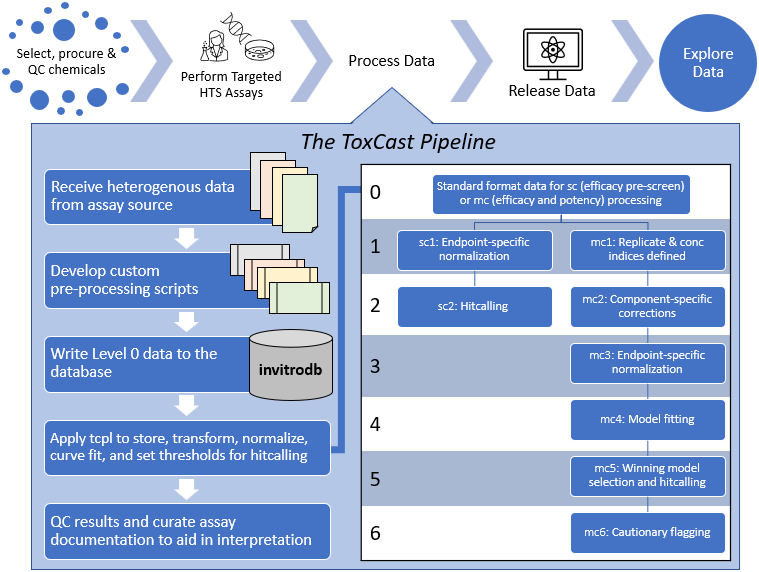

*Conceptual overview of the ToxCast Pipeline*

The [ToxCast Data Analysis Pipeline (`tcpl`)](https://CRAN.R-project.org/package=tcpl) is an R package that manages, curve-fits, plots, and stores ToxCast data to populate its linked MySQL database, invitrodb. `tcpl` is a flexible analysis pipeline capable of efficiently processing and storing large volumes of data. The diverse data, received in heterogeneous formats from numerous vendors, are transformed to a standard computable format and loaded into the `tcpl` database by vendor-specific R scripts. Once data is loaded into the database, ToxCast utilizes generalized processing functions provided in this package to process, normalize, model, qualify, and visualize the data. Check out [`tcpl`’s vignette](https://cran.r-project.org/web/packages/tcpl/index.html) for more comprehensive documentation describing ToxCast data processing, retrieval, and interpretation.

# 2 Highlights

Invitrodb v4.3 includes the following notable updates:

# 3 Known Issues in invitrodb v4.3

- The current model optimization implementation in `tcplfit2` uses the Nelder-Mead algorithm. In some cases, this may produce different model fits for the same data mirrored about the x-axis (i.e., negative vs positive response fits, or “flipped data”).

# 4 Accessibility

ToxCast data is accessible via:

- [CompTox Chemicals Dashboard](https://comptox.epa.gov/dashboard/)
- [Computational Toxicology and Exposure (CTX) Bioactivity API](https://www.epa.gov/comptox-tools/computational-toxicology-and-exposure-apis)
- [ToxCast Downloadable Data](https://www.epa.gov/comptox-tools/exploring-toxcast-data)

Consult documentation on each resource for more information regarding use and versioning.

## 4.1 CompTox Chemicals Dashboard

CCD’s ToxCast bioactivity module presents a view of potency and relative efficacy metrics across ToxCast endpoints for chemicals of interest. Users can easily sort, filter, and export ToxCast results and assay descriptions. As of August 2025, ToxCast data reflects invitrodb v4.1.

## 4.2 CTX APIs

Computational Toxicology and Exposure APIs (CTX APIs) make EPA’s computational landscape easily available. Data domains include Bioactivity, Chemical, Exposure, and Hazard. Visit the CTX APIs webpage for more information. As of August 2025, CTX Bioactivity API is sourced from the ToxCast’s invitrodb v4.1.

## 4.3 Data Downloads

Data downloads allow users to set up their own personal instance of the invitrodb MySQL database and interact with the data directly via the tcpl R package. This is a preferred option for more customized or programmatic ToxCast data needs, or if users want to do their own data processing. The [ToxCast Downloadable Data webpage](https://www.epa.gov/comptox-tools/exploring-toxcast-data) includes the following:

- Release note: Document describing changes in the database and software between versions
- Summary files: Zip file containing chemical by assay variable matrix output, assay annotations, cytotoxicity burst output, and assay-gene mappings in Excel and Rdata formats. Excel files of the provided outside of zip file in addition for convenience.
- Descriptions of all summary files included in README
- Assay Description Documents
- Plots: PDFs of all plots by assay source for all single and multi-concentration data
- MySQL data: Database dump file (.sql) with installation instructions available in README

# 5 Loading data

## 5.1 Set tcplConf and connections

- `tcplConf()` from `tcpl` is used to connect to the MySQL database, invitrodb v4.2. Data is also accessible via CCD or the CTX Bioactivity APIs.
- The `RMySQL` package is no longer supported with `tcpl` and will automatically be detached prior to use.

## 5.2 Load invitrodb v4.2

- Endpoint-level annotation information combined with invitrodb.gene and invitrodb.intended_target tables to provide information about technological design and biological assay coverage.
- Chemical level annotations as well as estimates of cytotoxicity, using invitrodb.cytotox table. This table stores the output of running `tcplCytoPt()` with default configuration and provides the lower bound estimate of the median, and the median, cytotoxicity threshold concentration estimate for the CompTox Chemicals Dashboard.
- Multi-concentration screening data at levels 5 and 6 (mc5 and mc6), which contain the summary of curve-fitting and hit-calling from use of `tcplfit2`.
- Single-concentration data at level 2 (sc2). The sc2 table contains a summary of the cutoff (`coff`) (threshold for positive), estimate of baseline (baseline median absolute deviation, or `bmad`), the maximum median effect for the single concentration screened (`max_med`), and ultimately the hitcall (requires that `max_med` > `coff`).

## 5.3 Load invitrodb v4.3

# 6 Database-level Review

This section examines changes in processed data between versions at the aggregate database-level.

## 6.1 Version Differences

```r
#create database comparison table
Output <- c("Assay Sources",
            "Assays",
            "Assay Components",
            "Assay Component Endpoints",
            "MC Samples",
            "SC Samples",
            "Chemicals",
            "MC Endpoint-Samples (M4IDs)",
            "SC Endpoint-Samples (S2IDs)",
            "Genes")
v4.2 <- c(length(unique(ace.old$asid)),
          length(unique(ace.old$aid)),
          length(unique(ace.old$acid)),
          length(unique(ace.old$aeid)),
          length(unique(old.mc5$spid)),
          length(unique(old.sc2$spid)),
          length(unique(chnm.old$chnm)),
          length(unique(old.mc5$m4id)),
          length(unique(old.sc2$s2id)),
          length(unique(gene.old$entrez_gene_id)))

v4.3 <- c(length(unique(ace.new$asid)),
          length(unique(ace.new$aid)),
          length(unique(ace.new$acid)),
          length(unique(ace.new$aeid)),
          length(unique(new.mc5$spid)),
          length(unique(new.sc2$spid)),
          length(unique(chnm.new$chnm)),
          length(unique(new.mc5$m4id)),
          length(unique(new.sc2$s2id)),
          length(unique(gene.new$entrez_gene_id)))

Change <- v4.3-v4.2
Table <- data.frame(Output, v4.2, v4.3, Change)
```

77 new endpoints and 873 chemicals were added in invitrodb v4.3 when compared to invitrodb v4.2. Additional metrics are provided in the table below.

|  | Output | v4.2 | v4.3 | Change |
| --- | --- | --- | --- | --- |
| 1 | Assay Sources | 26 | 29 | 3 |
| 2 | Assays | 655 | 717 | 62 |
| 3 | Assay Components | 1570 | 1647 | 77 |
| 4 | Assay Component Endpoints | 1570 | 1647 | 77 |
| 5 | MC Samples | 48200 | 48934 | 734 |
| 6 | SC Samples | 33854 | 37776 | 3922 |
| 7 | Chemicals | 9614 | 10487 | 873 |
| 8 | MC Endpoint-Samples (M4IDs) | 3332603 | 3517906 | 185303 |
| 9 | SC Endpoint-Samples (S2IDs) | 510971 | 533696 | 22725 |
| 10 | Genes | 560 | 577 | 17 |

## 6.2 Database Change Over Time

Since its inception in 2013, ToxCast is continually growing as a data resource as reflected by generally increasing numbers of DTXSID, endpoints, and numbers of genes covered.

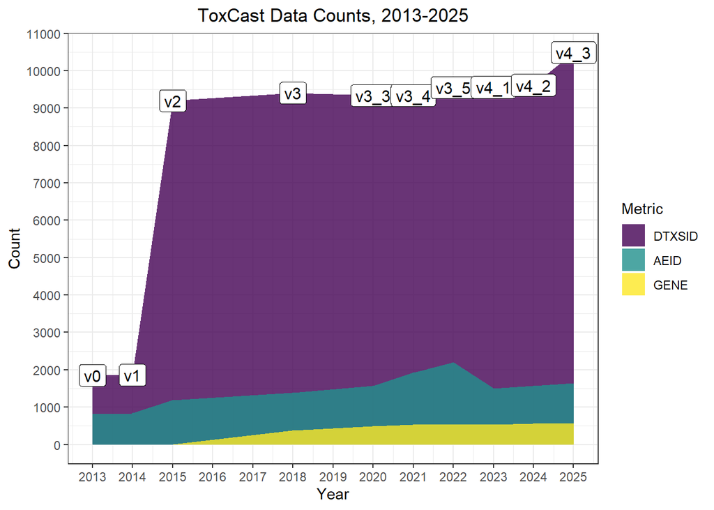

## 6.3 MC Hit Calls

In v4.2 and v4.3, hit calls (`hitc`) are continuous values calculated as the product of three proportional weights: 1) determination of whether at least one median response is outside the user specified cutoff band, 2) whether the `top` is outside the cutoff band, 3) and whether the winning model AIC is less than the constant model indicating a better fit than noise.

For current ToxCast work, a `hitc` greater than or equal to 0.90 is labeled active, whereas anything less was considered inactive. The threshold of 0.90 was based on other `tcplfit2` implementations with *in vitro* screening data [(Nyffeler et al., 2023)](https://www.sciencedirect.com/science/article/pii/S0041008X23001527) and reflects the apparent bimodal nature of the `hitc` distribution, where a preponderance of the `hitc` fall between 0 and 0.1 and 0.9 and 1.0. Users may interpret the continuous `hitc` into active or inactive designations based on different thresholds. Further testing through implementation of this new functionality may reveal appropriate thresholds for different applications or assays. The “unable to fit” series appear as model “none” with a hit call of 0, therefore inactive. In the `tcpl` v3.2 update, the mc4 bidirectional false method was replaced with new mc5 overwrite bidirectional methods. Instead of forcing data to fit in the positive analysis direction with the bidirectional_false method, all data now is fit bidirectionally, then the overwrite methods will multiply the continuous hit call value by -1 if top is not in intended direction. Previously “inactive” endpoint samples may appear with negative hitc if response was observed in unintended direction. Negative `hitc` values may be interpreted as response changes that are ‘not applicable’ (NA) and may indicate assay interference.

```r
#binary continuous hitcalls (hitc) into activity calls (actc)
new.mc5[hitc >= 0.9, actc:= 'active']
new.mc5[hitc >= 0 & hitc < 0.9, actc:= 'inactive']
new.mc5[hitc < 0, actc:= 'NA']

old.mc5[hitc >= 0.9, actc:= 'active']
old.mc5[hitc >= 0 & hitc < 0.9, actc:= 'inactive']
old.mc5[hitc < 0, actc:= 'NA']

#subset to only endpoint/samples in v4.2
new.mc5$endpoint_sample <- paste0(new.mc5$aeid, "_", new.mc5$spid)
old.mc5$endpoint_sample <- paste0(old.mc5$aeid, "_", old.mc5$spid)
crossover.mc5 <- new.mc5[endpoint_sample %in% old.mc5$endpoint_sample,]
#remove old samples that were retracted in v4.3
crossover.mc5 <- crossover.mc5[endpoint_sample %in% new.mc5$endpoint_sample,]

agg_hitc_old <- old.mc5 %>%
  group_by(actc) %>%
  count() %>%
  ungroup() %>%
  mutate(perc = `n` / sum(`n`)) %>%
  arrange(perc) %>%
  mutate(labels = scales::percent(perc))
agg_hitc_old$version <- "v4.2"
setnames(agg_hitc_old, "actc", "group")

agg_hitc_new <- crossover.mc5 %>%
  group_by(actc) %>%
  count() %>%
  ungroup() %>%
  mutate(perc = `n` / sum(`n`)) %>%
  arrange(perc) %>%
  mutate(labels = scales::percent(perc))
agg_hitc_new$version <- "v4.3"
setnames(agg_hitc_new, "actc", "group")

agg_hitc<- rbind(agg_hitc_old, agg_hitc_new)
agg_hitc$group <- factor(agg_hitc$group, levels = c("inactive", "active", "NA"))

diff <- as.data.table(setdiff(old.mc5$endpoint_sample, crossover.mc5$endpoint_sample))
```

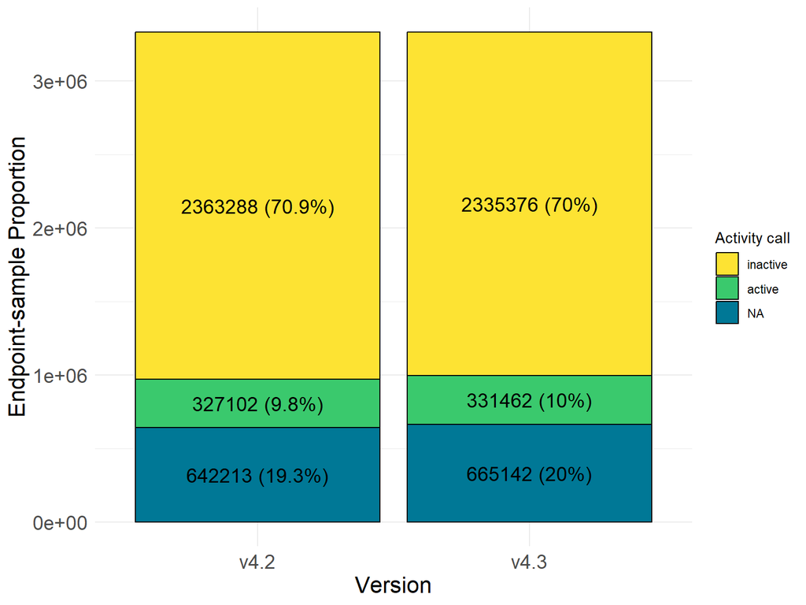

```r
ggplot(agg_hitc, aes(x = version, y= n, fill = group)) +
  geom_bar(colour="black", stat = "identity", position = position_stack()) +
  theme_minimal() +
  scale_fill_manual(values=c("#FDE333", "#3AC96D", "#007896")) +
  guides(fill = guide_legend(title = "Activity call")) +
  labs(y = "Endpoint-sample Proportion", x= "Version") +
  theme(axis.text = element_text(size=14),
        axis.title = element_text(size=16))+
  geom_text(aes(label = paste0(n, " (", labels, ")")), position = position_stack(vjust=0.5), size=5)
```

When examined, the distribution of the v4.3 continuous hitc is **not** normally distributed, and values skew towards 0 and 1. All data is bidirectionally fit regardless of the intended direction of biological effect. If a particular direction is considered not biologically interpretable, a negative hit call value will indicate this.

The hit call itself is not a probability of a hit. It is a continuous value, but essentially one that should be interpreted in a binary way. Given the distribution of values is not a product of probabilities, so it is appropriate to binarize these values into active and inactive designations. Future work is being done to update hit calling logic so hitc more accurately reflect borderline or noisy cases.

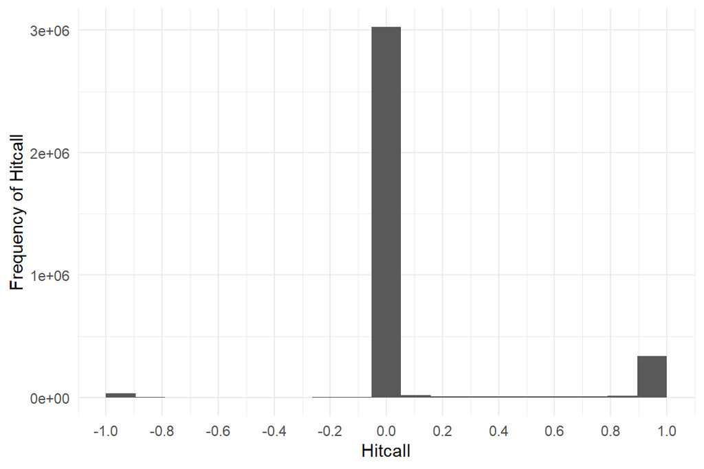

```r
ggplot(data=new.mc5) +
  geom_histogram(aes(x=hitc), bins=20)+
  xlab('Hitcall')+
  ylab('Frequency of Hitcall')+
  scale_x_continuous(breaks=seq(-1,1,0.2))+
  theme_bw()+
  theme(axis.title.x = element_text(face='bold', size=14),
        axis.title.y = element_text(face='bold', size=14),
        axis.text.x = element_text(size=12),
        axis.text.y = element_text(size=12)) + theme_minimal()
```

## 6.4 Impacts of LOEC Update on Winning Model Selection

This data was filtered to remove endpoint-samples that were inactive between both versions. Models included: “hill”, “gnls”(Gain-Loss), “pow”(power), “poly1”(polynomial-1: linear), “poly2”(polynomial-2: quadratic), “exp2”(exponential-2), “exp3”(exponential-3), “exp4”(exponential-4), “exp5”(exponential-5), “loec” (lowest observed effective concentration).

The LOEC method was re-implemented for the BioSeek (BSK) assay source to align with past publications ([Houck et al., 2021](https://pubmed.ncbi.nlm.nih.gov/33887376/)). A LOEC in `tcpl` is defined as the lowest experimental dose where all responses surpass the cutoff. If a LOEC is determined, the concentration-response also has an active hitcall. The number of actives with LOEC as their winning model is **14.28% in v4.3** as evident in the figure below.

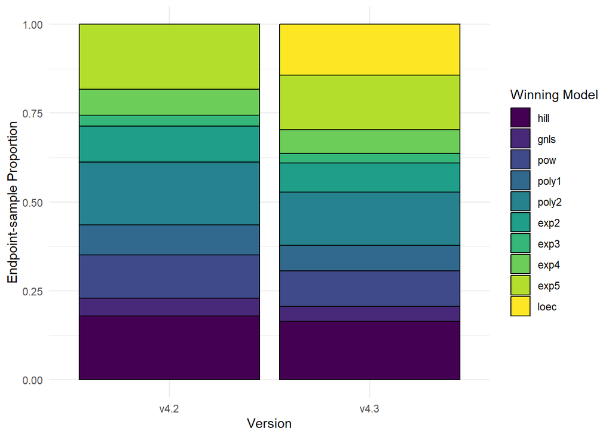

```r
modl_agg_old <- old.mc5 %>%
  filter(old_actc %in% 'active') %>%
  group_by(old_modl) %>%
  filter(!is.na(old_modl)) %>%
  count() %>%
  ungroup() %>%
  mutate(perc = `n` / sum(`n`)) %>%
  arrange(perc) %>%
  mutate(labels = scales::percent(perc))
modl_agg_old$version <- "v4.2"
setnames(modl_agg_old, "old_modl", "modl")

modl_agg_new <- crossover.mc5 %>%
  filter(new_actc %in% 'active') %>%
  group_by(new_modl) %>%
  count() %>%
  ungroup() %>%
  mutate(perc = `n` / sum(`n`)) %>%
  arrange(perc) %>%
  mutate(labels = scales::percent(perc))
modl_agg_new$version <- "v4.3"
setnames(modl_agg_new, "new_modl", "modl")

modl_agg_comp<- rbind(modl_agg_old, modl_agg_new)

modl_agg_comp$modl<-factor(modl_agg_comp$modl, levels = c("hill", "gnls", "cnst", "pow", "poly1", "poly2", "exp2", "exp3", "exp4", "exp5", "none", "loec"))

ggplot(modl_agg_comp, aes(x = version, y= n, fill = modl)) + geom_bar(colour="black", stat = "identity", position = position_fill(reverse = TRUE)) +
  scale_fill_viridis_d() +
  guides(fill = guide_legend(title = "Winning Model")) +
  theme(axis.text.x = element_text(angle = 65,
                                   vjust = 1,
                                   hjust = 1), text=element_text(size=20),
        plot.title = element_text(hjust = 0.5, face = "bold"),
        legend.key.size = unit(1, 'cm'), #change legend key size
        legend.key.height = unit(1, 'cm'), #change legend key height
        legend.key.width = unit(1, 'cm'), #change legend key width
        legend.title = element_text(size=20), #change legend title font size
        legend.text = element_text(size=20)) + #change legend text font size
  labs(y = "Endpoint-sample Proportion", x="Version") + theme_minimal()
```

```r
datatable(modl_agg_comp,
          filter='top',
          options=list(pagelength=25, autoWidth=FALSE,  scrollX=TRUE, initComplete = JS(
    "function(settings, json) {",
    "$('body').css({'font-family': 'Calibri'});",
    "}"
  )))
```

|  | modl | n | perc | labels | version |
| --- | --- | --- | --- | --- | --- |
| 1 | exp3 | 10027 | 0.03065404674994344 | 3.07% | v4.2 |
| 2 | gnls | 16255 | 0.0496939792480633 | 4.97% | v4.2 |
| 3 | exp4 | 24044 | 0.0735061234721891 | 7.35% | v4.2 |
| 4 | poly1 | 27575 | 0.08430092142512122 | 8.43% | v4.2 |
| 5 | exp2 | 33089 | 0.1011580485597765 | 10.12% | v4.2 |
| 6 | pow | 39947 | 0.1221239857903651 | 12.21% | v4.2 |
| 7 | poly2 | 57760 | 0.1765810053133273 | 17.66% | v4.2 |
| 8 | hill | 58798 | 0.1797543273963473 | 17.98% | v4.2 |
| 9 | exp5 | 59607 | 0.1822275620448667 | 18.22% | v4.2 |
| 10 | exp3 | 9017 | 0.0272037216935878 | 2.72% | v4.3 |

[output cut: 9 more lines]

## 6.5 Cautionary Flag Review

Cautionary flags on curve fitting can provide context to interpret potential false positives (or negatives) in ToxCast data, enabling the user to decide the stringency with which to filter these targeted in vitro screening data. Cautionary flags include:

|  | mc6_mthd_id | flag |
| --- | --- | --- |
| 1 | 5 | Model directionality questionable |
| 2 | 6 | Active with only highest conc above baseline (3*bmad) |
| 3 | 7 | Active with one conc (not highest) above baseline (3*bmad) |
| 4 | 8 | Inactive with multiple concs above baseline (3*bmad) |
| 5 | 9 | Bmd &gt; ac50, indication of high baseline variability |
| 6 | 10 | Noisy data |
| 7 | 11 | Borderline |
| 8 | 13 | Average number of replicates per conc &lt; 2 |
| 9 | 14 | Number of concentrations tested &lt; 4 |
| 10 | 15 | Gain AC50 &lt; lowest conc &amp; loss AC50 &lt; mean conc |

[output cut: 4 more lines]

We can examine the number of flags for active endpoint-samples. Most active endpoint-samples have 0, 1, or 2 flags.

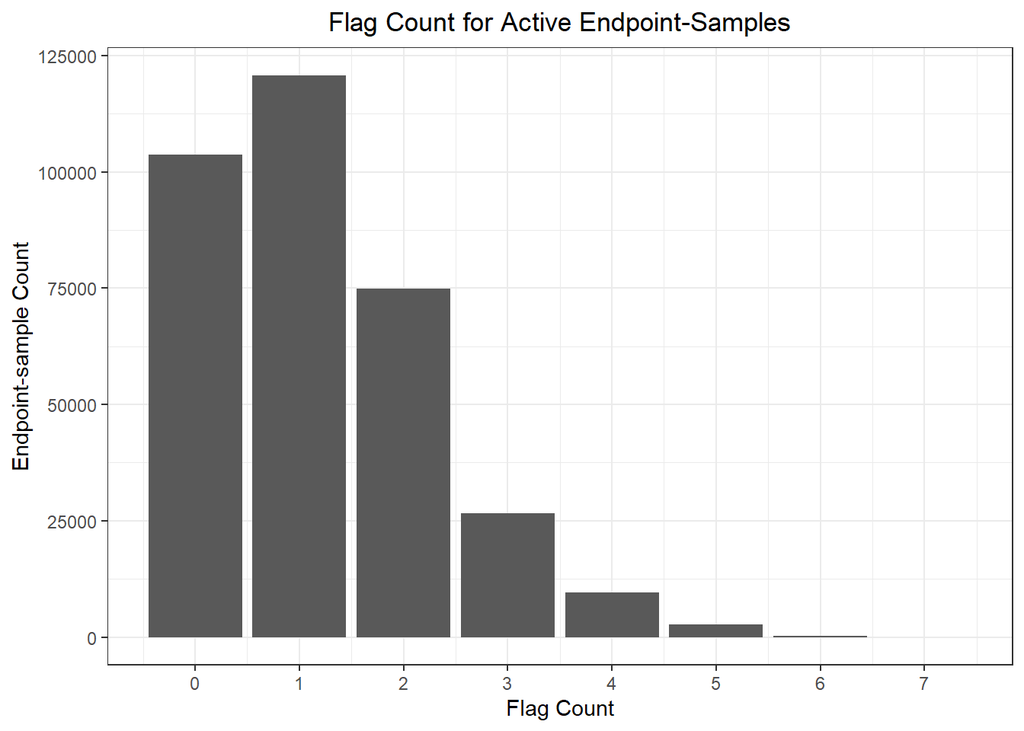

```r
new.mc5[is.na(flag.length), flag.length := 0]
new.mc5.pos <- new.mc5[actc == 'active',]

ggplot(data=new.mc5.pos)+
  geom_bar(aes(x=flag.length), stat='count')+
  theme_bw()+
  ylab('Endpoint-sample Count')+
  ggtitle('Flag Count for Active Endpoint-Samples')+
  theme(plot.title= element_text(hjust=0.5))+
  scale_x_continuous(name='Flag Count',breaks=seq(0,7,1))
```

Below is a table of the counts of m4ids (n) that have a particular fit category (fitc) and flag combination, showing only those m4ids with 3 or more flags and hitc >= 0.9 (only positives). Ongoing work will be needed to understand if flags correspond to curve-fits of lower confidence.

|  | mc6_flags | fitc | actc | n |
| --- | --- | --- | --- | --- |
| 1 | 13,14,17 | 100 | active | 5395 |
| 2 | 9,13,14,17 | 100 | active | 4902 |
| 3 | 9,13,17 | 100 | active | 4266 |
| 4 | 6,13,17 | 41 | active | 3616 |
| 5 | 9,14,17 | 100 | active | 2855 |
| 6 | 6,9,17 | 41 | active | 2690 |
| 7 | 9,11,13,14,17 | 100 | active | 1668 |
| 8 | 11,13,17 | 37 | active | 977 |
| 9 | 9,13,17 | 41 | active | 664 |
| 10 | 9,11,13,17 | 100 | active | 630 |

[output cut: 272 more lines]

In general, 1-3 flags may not signify poor fits; indeed some most common flags is simply fewer than 2 replicates per concentration or less than 50% efficacy (which may be commonly observed for assays that are not focused on pharmacological receptor interaction). Flags may encompass assay design. Combining flags and fit category, as shown in Plot A, may provide appropriate measures to clean data sets for further interpretation for particular use cases. See the Data Interpretation sections on Flags and Fit Categories for more details.

Fit categories describe the nature of the curve fit, including its efficacy relative to the cutoff and its potency relative to the concentrations included in the assay. We can examine specific fitc, such as fitc 36 and 40 which both reflect predicted potency values below the concentration range screened (AC50 <= logc_min). Fitc 36 has low relative efficacy (|top|<=1.2*coff) and relates to the least reliable quantitative potency predictions. Plot B illustrates low confidence curves also reflect high presence of flags.

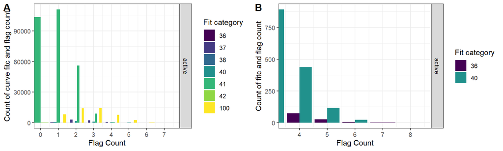

```r
new.mc5.pos.ct <- new.mc5.pos[,list(
  behavior.ct = .N
), by=list(flag.length, fitc, actc)] %>% data.table()

new.mc5.pos.ct <- new.mc5.pos.ct[!is.na(fitc)]
new.mc5.pos.ct <- new.mc5.pos.ct[order(-behavior.ct)]

all <- ggplot(data=new.mc5.pos.ct, aes(x=flag.length, y = behavior.ct, fill=as.factor(fitc)))+
       geom_bar(position='dodge', stat='identity')+
  theme_bw()+
  facet_grid(rows = 'actc')+
  scale_fill_viridis(name = 'Fit category',discrete=TRUE)+
  ylab('Count of curve fitc and flag count')+
  xlab('Flag count')+
scale_x_continuous(name='Flag Count',breaks=seq(0,7,1))+
  coord_cartesian(xlim=c(0,7.5))

gt3flags <- ggplot(data=new.mc5.pos.ct[flag.length>2 & fitc %in% c(36,40) & actc =="active",], aes(x=flag.length, y = behavior.ct, fill=as.factor(fitc)))+
       geom_bar(position='dodge', stat='identity')+
  theme_bw()+
  facet_grid(rows = 'actc')+
  scale_fill_manual(name = "Fit category", values=c("#440154", "#21918c")) + # "#"
  ylab('Count of fitc and flag count')+
  xlab('Flag count > 2 and Fitc in 36 or 40')+
scale_x_continuous(name='Flag Count',breaks=seq(3,8,1))+
  coord_cartesian(xlim=c(3.5,8.5))

plot_grid(all, gt3flags, ncol=2, labels=c('A','B'), label_size = 14)
```

## 6.6 Impacts to Potency Distributions

Point of departure potency estimates were based on modeled active concentration series, including ACC (activity concentration at cutoff), AC10 (activity concentration at 10% of maximal response), and AC50 (activity concentration at 50% of maximal response). `tcplfit2` modeling has incorporated new potency and uncertainty estimates, based on the BMDExpress transcriptomics dose-response modeling software [(Phillips et al, 2019)](https://doi.org/10.1093/bioinformatics/bty878), which includes benchmark dose (BMD) estimation (that is the dose at which a defined Benchmark Response (BMR) level occurs). The BMR is defined to be one standard deviation shift from the baseline response for the endpoint(s) of interest. As a new update, the baseline response is estimated using the two lowest concentrations across all tested chemicals or neutral controls, depending on what the endpoint used.

To examine the potency distributions, data was first filtered to remove endpoint-samples that were inactives and only endpoint-samples in both versions. The following analysis examines $log_{10}$ potency values, or the log-transformed experimental concentrations in uM. For a more equitable comparison, this analysis will only consider the v4.3 mc5 with endpoint samples included in v4.2.

Comparing the $log_{10}$ potency distributions, potency estimates remain consistent between versions, with the exception of ACCs for inactive and NAs hitcalls. ACCs outside the experimental concentration range cannot be derived and are NA in v4.3. This is improvement from v4.2 as extrapolating potency estimates without sufficient data of the biological response in higher doses is not appropriate.

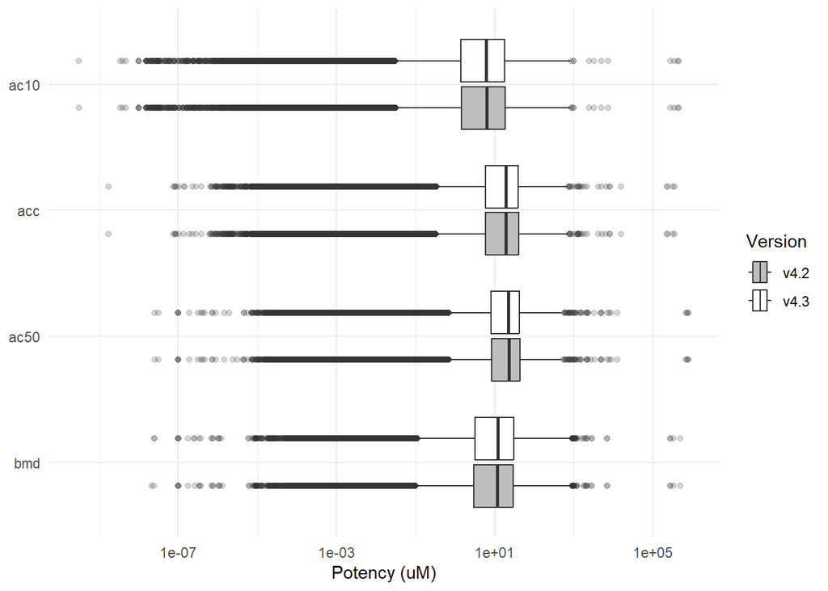

```r
colnames(crossover.mc5) <- str_replace(colnames(crossover.mc5), "new_", "")
colnames(old.mc5) <- str_replace(colnames(old.mc5), "old_", "")
potency <-rbind(crossover.mc5, old.mc5, fill=TRUE)

potency[hitc >= 0.9, actc:= 'active']
potency[hitc >= 0 & hitc < 0.9, actc:= 'inactive']
potency[hitc < 0, actc:= 'NA']
potency_active <- potency[actc=='active',]

potency_agg_comp_long <- as.data.table(melt(potency_active,
                                  # ID variables - all the variables to keep but not split apart on
                                  id.vars=c("spid" ,"aeid", "version", "actc"),
                                  # The source columns
                                  measure.vars=c( "bmd","ac50", "acc", "ac10"),
                                  # Name of the destination column that will identify the original
                                  # column that the measurement came from
                                  variable.name="potency",
                                  value.name="value"))

#filter to remove instances if NA in either one version (limit to values used in stat test comparison)
potency_agg_comp_long <- potency_agg_comp_long %>%
  group_by(spid, aeid, potency) %>%
    filter(!any(is.na(value)))

ggplot(data = potency_agg_comp_long, aes(x = value, y = potency, fill=version, na.rm=TRUE)) +
  geom_boxplot(outlier.alpha = 0.2) + theme_minimal() +
  theme(strip.background = element_blank(),
        strip.text.y = element_text(angle=360)) +
  scale_x_log10()+
  scale_fill_manual(values = c("gray", "white")) +
  labs(y= NULL, x = "Potency (uM)") +
  guides(fill = guide_legend(title = "Version"))
```

Activity call in relation to each of these potency values can be considered.

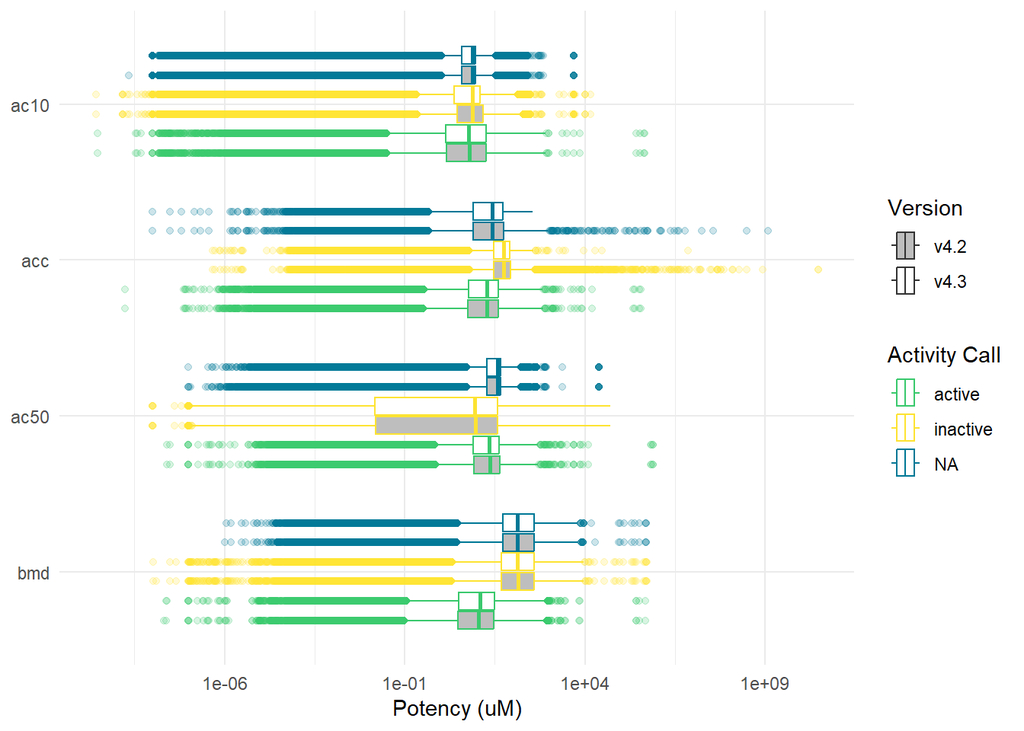

```r
potency_agg_comp_long_all <- as.data.table(melt(potency,
                                  # ID variables - all the variables to keep but not split apart on
                                  id.vars=c("spid" ,"aeid", "version", "actc"),
                                  # The source columns
                                  measure.vars=c( "bmd","ac50", "acc", "ac10"),
                                  # Name of the destination column that will identify the original
                                  # column that the measurement came from
                                  variable.name="potency",
                                  value.name="value"))

ggplot(data = potency_agg_comp_long_all, aes(x = value, y = potency, color=actc, fill=version, na.rm=TRUE)) +
  geom_boxplot(outlier.alpha = 0.2) + theme_minimal() +
  theme(strip.background = element_blank(),
        strip.text.y = element_text(angle=360)) +
  scale_x_log10()+
  scale_fill_manual(values = c("gray", "white")) +
   scale_color_manual(values=c("#3AC96D", "#FDE333", "#007896")) +
  labs(y= NULL, x = "Potency (uM)") +
  guides(color = guide_legend(title = "Activity Call"), fill = guide_legend(title = "Version"))
```

## 6.7 SC Hit Calls

```r
#binary hitcalls (hitc) into activity calls (actc)
new.sc2[hitc == -1, actc:= 'NA']
new.sc2[hitc == 0, actc:= 'inactive']
new.sc2[hitc == 1,  actc:= 'active']

old.sc2[hitc == -1, actc:= 'NA']
old.sc2[hitc == 0, actc:= 'inactive']
old.sc2[hitc == 1, actc:= 'active']

#subset to only endpoint/samples in v4.2
new.sc2$endpoint_sample <- paste0(new.sc2$aeid, "_", new.sc2$spid)
old.sc2$endpoint_sample <- paste0(old.sc2$aeid, "_", old.sc2$spid)
crossover.sc2 <- new.sc2[endpoint_sample %in% old.sc2$endpoint_sample,]

sc_agg_hitc_old <- old.sc2 %>%
  group_by(actc) %>%
  count() %>%
  ungroup() %>%
  mutate(perc = `n` / sum(`n`)) %>%
  arrange(perc) %>%
  mutate(labels = scales::percent(perc))
sc_agg_hitc_old$version <- "v4.2"
setnames(sc_agg_hitc_old, "actc", "group")

sc_agg_hitc_new <- new.sc2 %>%
  group_by(actc) %>%
  count() %>%
  ungroup() %>%
  mutate(perc = `n` / sum(`n`)) %>%
  arrange(perc) %>%
  mutate(labels = scales::percent(perc))
sc_agg_hitc_new$version <- "v4.3"
setnames(sc_agg_hitc_new, "actc", "group")

sc_agg_hitc_cross <- crossover.sc2 %>%
  group_by(actc) %>%
  count() %>%
  ungroup() %>%
  mutate(perc = `n` / sum(`n`)) %>%
  arrange(perc) %>%
  mutate(labels = scales::percent(perc))
sc_agg_hitc_cross$version <- "v4.3"
setnames(sc_agg_hitc_cross, "actc", "group")

sc_agg_hitc<- rbind(sc_agg_hitc_old, sc_agg_hitc_new)
sc_agg_hitc$group <- factor(sc_agg_hitc$group, levels = c("inactive", "active", "NA"))

sc_agg_hitc_cross<- rbind(sc_agg_hitc_old, sc_agg_hitc_cross)
sc_agg_hitc_cross$group <- factor(sc_agg_hitc_cross$group, levels = c("inactive", "active", "NA"))
```

For a more equitable comparison, this analysis will only consider the v4.3 single-conc data with endpoint samples included in v4.2. As with multi-conc data, negative hit calls were introduced after bidirectional fitting to describe responses in the non-biologically intrepretable direction.

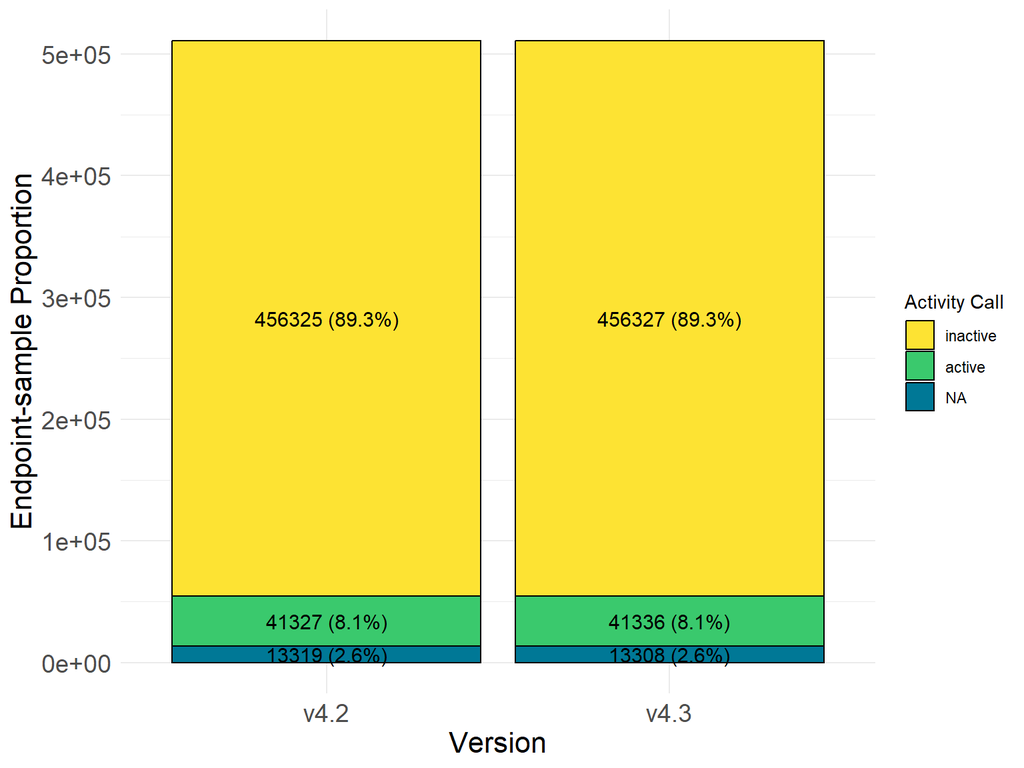

```r
ggplot(sc_agg_hitc_cross, aes(x = version, y= n, fill = group)) +
  geom_bar(colour="black", stat = "identity", position = position_stack()) +
  theme_minimal() +
  scale_fill_manual(values=c("#FDE333", "#3AC96D", "#007896")) +
  guides(fill = guide_legend(title = "Activity Call")) +
  labs(y = "Endpoint-sample Proportion", x= "Version") +
  theme(axis.text = element_text(size=14),
        axis.title = element_text(size=16))+
  geom_text(aes(label = paste0(n, " (", labels, ")")), position = position_stack(vjust=0.5), size = 4)
```

## 6.8 Gene Coverage

For invitrodb v4.3, over 72% of endpoints (1194/1649) have gene mappings, represented by 577 unique genes. 19 new genes were added. These new genes associated include:

```r
new.genes <- setdiff(gene.new$entrez_gene_id, gene.old$entrez_gene_id)
new.genes2 <- gene.new[entrez_gene_id %in% new.genes, c('entrez_gene_id','official_full_name', 'official_symbol')]
new.genes3 <- distinct(new.genes2)

datatable(new.genes3,
          filter='top',
          options=list(pagelength=25, autoWidth=FALSE,  scrollX=TRUE, initComplete = JS(
    "function(settings, json) {",
    "$('body').css({'font-family': 'Calibri'});",
    "}"
  )))
```

|  | entrez_gene_id | official_full_name | official_symbol |
| --- | --- | --- | --- |
| 1 | 5430 | RNA polymerase II subunit A | POLR2A |
| 2 | 116160065 | luciferin 4-monooxygenase | LOC116160065 |
| 3 | 3357 | 5-hydroxytryptamine receptor 2B | HTR2B |
| 4 | 4161 | melanocortin 5 receptor | MC5R |
| 5 | 397481 | ATPase Na+/K+ transporting subunit alpha 1 | ATP1A1 |
| 6 | 2475 | mechanistic target of rapamycin kinase | MTOR |
| 7 | 5291 | phosphatidylinositol-4,5-bisphosphate 3-kinase catalytic subunit beta | PIK3CB |
| 8 | 5742 | prostaglandin-endoperoxide synthase 1 | PTGS1 |
| 9 | 775 | calcium voltage-gated channel subunit alpha1 C | CACNA1C |
| 10 | 1268 | cannabinoid receptor 1 | CNR1 |

[output cut: 9 more lines]

Two gene mappings were removed from v4.2:

- 1. luciferase cloning vector was removed as non-gene
- 2. jun proto-oncogene (FOS|JUN) gene mapping was updated for the TOX21_AP1_BLA_Agonist_ratio endpoint with extraneous gene mapping removed

## 6.9 AOP and KE Coverage

```r
tcplConf(user="mfeshuk", pass = "5jHbwy$yLDG-y5nC", db="invitrodb", drvr="MySQL", host="v2626umcth869.rtord.epa.gov")
aop <- tcplQuery("SELECT target_id as aop, count(aeid) FROM invitrodb.intended_target where target_type='aop' group by target_id;")
ke <- tcplQuery("SELECT target_id as key_event, count(aeid) FROM invitrodb.intended_target where target_type='key_event' group by target_id;")

setDT(aop)
aop <- aop[,aop := paste0("<a href=https://aopwiki.org/aops/",aop,">",aop,"</a>")]

setDT(ke)
ke <- ke[,key_event := paste0("<a href=https://aopwiki.org/events/",key_event,">",key_event,"</a>")]

datatable(aop,
          filter='top', escape=FALSE,
          options=list(pagelength=25, autoWidth=FALSE,  scrollX=TRUE, initComplete = JS(
    "function(settings, json) {",
    "$('body').css({'font-family': 'Calibri'});",
    "}"
  )))
```

|  | aop | count(aeid) |
| --- | --- | --- |
| 1 | 3 | 1 |
| 2 | 6 | 1 |
| 3 | 12 | 11 |
| 4 | 13 | 18 |
| 5 | 17 | 8 |
| 6 | 21 | 2 |
| 7 | 23 | 34 |
| 8 | 25 | 2 |
| 9 | 38 | 12 |
| 10 | 42 | 10 |

[output cut: 27 more lines]

```r
datatable(ke,
          filter='top', escape=FALSE,
          options=list(pagelength=25, autoWidth=FALSE,  scrollX=TRUE, initComplete = JS(
    "function(settings, json) {",
    "$('body').css({'font-family': 'Calibri'});",
    "}"
  )))
```

|  | key_event | count(aeid) |
| --- | --- | --- |
| 1 | 18 | 2 |
| 2 | 25 | 25 |
| 3 | 28 | 13 |
| 4 | 36 | 2 |
| 5 | 52 | 3 |
| 6 | 55 | 8 |
| 7 | 202 | 1 |
| 8 | 274 | 2 |
| 9 | 277 | 2 |
| 10 | 279 | 4 |

[output cut: 29 more lines]

## 6.10 Assay Lists

In addition to updating existing assay lists in invitrodb, a new assay list for “Mitochondrial Toxicity” have been added in invitrodb v4.3. The table below summarizes the available assay lists and endpoint counts per list. Note that endpoints can be associated with multiple assay lists.

The assay lists previously annotated as “EDSP” have been updated. The assay endpoints associated with the ToxCast ER and AR pathway models are denoted. There are also updated lists for Steroidogenesis and Thyroid Bioactivity. Additional new lists have been added, including one for the “DNT-IVB,” or the developmental neurotoxicity in vitro battery.

|  | name | description | count(aeid) |
| --- | --- | --- | --- |
| 1 | Cytotoxicity Burst | Assays used to defne the cytotoxicity burst region | 76 |
| 2 | ToxCast ER Pathway Model | Estrogen receptor assays used in ToxCast ER Pathway model. See 10.1093/toxsci/kfv168 | 21 |
| 3 | ToxCast AR Pathway Model | Androgen receptor assays used in ToxCast AR Pathway model. See 10.1016/j.yrtph.2020.104764 and 10.1021/acs.chemrestox.6b00347 | 17 |
| 4 | Non-mammalian Vertebrate | Assays associated with non-mammalian vertebrate species | 98 |
| 5 | Thyroid Bioactivity | Assays related to the thyroid adverse outcome pathway network | 69 |
| 6 | Immunosuppression | Assays associated with markers of immunosuppression, see 10.14573/altex.2203041 | 6 |
| 7 | Developmental Toxicity | Assays associated with developmental toxicity | 82 |
| 8 | Steroidogenesis Bioactivity | Assays related to steroidogenesis | 29 |
| 9 | DNT-IVB | Assays included in the developmental neurotoxicity in vitro battery, see https://www.regulations.gov/document/EPA-HQ-OPP-2020-0263-0006 | 68 |
| 10 | Cardiotoxicity | Assays associated with cardiotoxicity | 5 |

[output cut: 1 more lines]

# 7 Assay Source-level Review

This section examines changes in processed data between versions at the assay source-level.

## 7.1 MC Assay Sources

Herein we explore the relative changes in activity calls (actc) by assay source between invitrodb v4.2 and this release, invitrodb v4.3. For a more equitable comparison, this analysis will only consider the v4.3 mc5 with endpoint samples included in v4.2. As in Database-level Review, MC Hit Calls, a hitc greater than or equal to 0.90 is labeled active, whereas anything less was considered inactive. A negative hitc for responses observed in unintended direction can interpreted as ‘not applicable’ (NA).

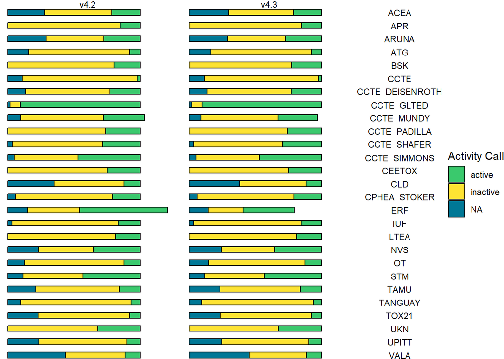

|  | asnm | version | actc | n | perc |
| --- | --- | --- | --- | --- | --- |
| 1 | ACEA | v4.2 | NA | 3928 | 13.85049365303244 |
| 2 | ACEA | v4.2 | active | 3047 | 10.74400564174894 |
| 3 | ACEA | v4.2 | inactive | 7205 | 25.40550070521862 |
| 4 | ACEA | v4.3 | NA | 4223 | 14.89069111424542 |
| 5 | ACEA | v4.3 | active | 3014 | 10.62764456981664 |
| 6 | ACEA | v4.3 | inactive | 6943 | 24.48166431593794 |
| 7 | APR | v4.2 | active | 3916 | 7.740354206198609 |
| 8 | APR | v4.2 | inactive | 21380 | 42.25964579380139 |
| 9 | APR | v4.3 | active | 3831 | 7.572343453510437 |
| 10 | APR | v4.3 | inactive | 21465 | 42.42765654648956 |

[output cut: 142 more lines]

The decrease in data observed for the ERF assay source is due to the redaction of the Estrogen and Androgen nuclear receptor assays (ERF_TW_NR_hERa, ERF_TW_NR_hAR) which undergoing additional QC.

## 7.2 BSK LOEC Analysis

For invitrodb v3.5, BSK endpoints employed a lowest-effect concentration (LOEC) method given the BSK assay design included limited number of concentrations tested and single replicates. With the updates in the `tcplfit2` package and bandwidth to include LOEC method in `tcpl` v3, benchmark dose (BMD) was used as an alternative estimate for BSK endpoints in invitrodb v4.1-2. For v4.3, we’ve re-implemented the LOEC method that was previously used for invitrodb v3.5. The advantage to utilizing a BMD include not having to rely on experimental concentration values, and this would be more consistent with the POD estimates derived from traditional modeling like other ToxCast assays. However, it is not necessarily the correct solution for all situations. Thus, an exploratory analyses was conducted to understand estimate is most appropriate for the endpoints in this assay platform.

### 7.2.1 v3.5 to v4.2 Comparison

#### 7.2.1.1 Flipped Hits

Flipped hit calls can be examined between versions. Deleted endpoints in v4.2 were mapped to the component level to assess overall change. Flip directions include: AA (active in both v3.5 and v4.2), AI (active in v3.5, but inactive in v4.2), II (inactive in both v3.5 and v4.2), or IA (inactive in v3.5, but active in v4.2).

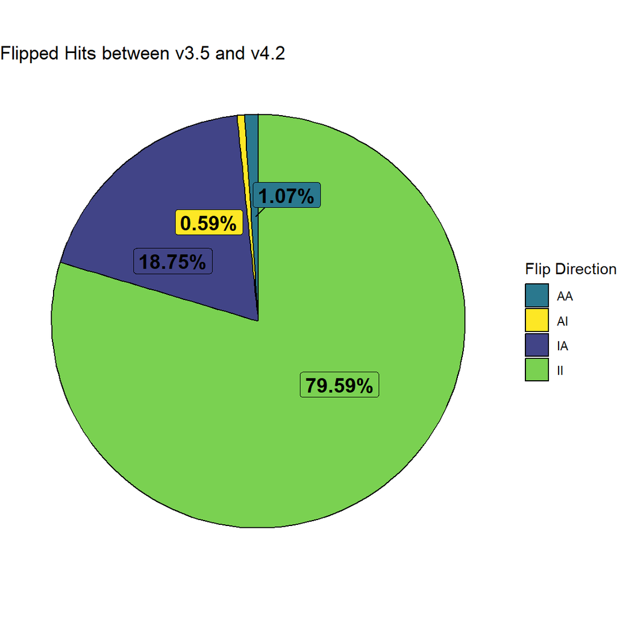

```r
ggplot(flips_pie, aes(x = "", y = perc, fill = flip_dir2)) +
  geom_bar(stat="identity", color="black") +
  ggrepel::geom_label_repel(aes(label = labels),
                            position = position_stack(vjust = .5),
                            show.legend = FALSE, fontface='bold', color='black', size=5) +
 scale_fill_manual(values=c('#2A788EFF', '#FDE725FF', '#414487FF','#7AD151FF'))+
  guides(fill = guide_legend(title = "Flip Direction")) +
  labs(title = "Flipped Hits between v3.5 and v4.2", y = "proportion") +
  coord_polar(theta = "y") + theme_void()
```

#### 7.2.1.2 Potency

Some summary statistics for POD differences are calculated. Given inactives often do not include potency estimates, data is subset to compare values in actives (AA):

```r
#subset remove rows where always inactive between versions since these often do not have potency values
potency1 <- dat2 %>%
  select(flip_dir2, comb_id, log10_bmd.loec_diff, log10_acc.loec_diff) %>%
  distinct() %>%
  filter(!flip_dir2 %in%  c("II","IA", "AI"))

summary(potency1$log10_bmd.loec_diff, na.rm=TRUE)
```

```
##     Min.  1st Qu.   Median     Mean  3rd Qu.     Max.     NA's
## -2.60206  0.03152  0.23161  0.21162  0.44977  2.30539      276
```

```r
summary(potency1$log10_acc.loec_diff, na.rm=TRUE)
```

```
##     Min.  1st Qu.   Median     Mean  3rd Qu.     Max.
## -2.10104  0.07437  0.20708  0.21747  0.36291  2.65360
```

### 7.2.2 v3.5 to v4.3 Comparison

#### 7.2.2.1 Flipped Hits

Flipped hit calls can be examined between versions. Deleted endpoints in v4.3 were mapped to the component level to assess overall change. Flip directions include: AA (active in both v3.5 and v4.3), AI (active in v3.5, but inactive in v4.3), II (inactive in both v3.5 and v4.3), or IA (inactive in v3.5, but active in v4.3).

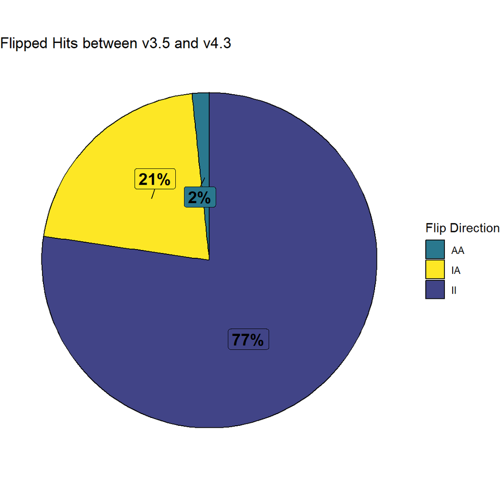

```r
ggplot(flips_pie, aes(x = "", y = perc, fill = flip_dir2)) +
  geom_bar(stat="identity", color="black") +
  ggrepel::geom_label_repel(aes(label = labels),
                            position = position_stack(vjust = .5),
                            show.legend = FALSE, fontface='bold', color='black', size=5) +
 scale_fill_manual(values=c('#2A788EFF', '#FDE725FF', '#414487FF','#7AD151FF'))+
  guides(fill = guide_legend(title = "Flip Direction")) +
  labs(title = "Flipped Hits between v3.5 and v4.3", y = "proportion") +
  coord_polar(theta = "y") + theme_void()
```

#### 7.2.2.2 Potency

Some summary statistics for POD differences were calculated.

```r
#subset remove rows where always inactive between versions since these often do not have potency values
potency1 <- dat5 %>%
  select(flip_dir2, comb_id, log10_pod_diff) %>%
  distinct() %>%
  filter(!flip_dir2 %in%  c("II","IA")) %>%
  filter(!is.na(log10_pod_diff))

summary(potency1$log10_pod_diff, na.rm=TRUE)
```

```
##     Min.  1st Qu.   Median     Mean  3rd Qu.     Max.
## -0.17319 -0.04139  0.00000 -0.01236  0.00000  1.79588
```

The median difference between LOECs was 0.00 log10 uM.

# 8 Endpoint-level Review

This section examines changes in processed data between versions at the individual endpoint-level.

## 8.1 New MC Endpoints

The 38 new endpoints released in v4.3 with multi-conc data include:

```r
new.mc.aeids <- setdiff(new.mc5$aeid, old.mc5$aeid)

datatable(ace.new[aeid %in% new.mc.aeids, c('aeid','assay_component_endpoint_name')],
          filter='top',
          options=list(pagelength=25, autoWidth=FALSE,  scrollX=TRUE, initComplete = JS(
    "function(settings, json) {",
    "$('body').css({'font-family': 'Calibri'});",
    "}"
  )))
```

|  | aeid | assay_component_endpoint_name |
| --- | --- | --- |
| 1 | 3071 | HCAN_AUR_hTPO |
| 2 | 3182 | ERF_US_NR_hAHR |
| 3 | 3183 | ERF_US_NR_hGR |
| 4 | 3184 | ERF_TW_IC_hKCNH2 |
| 5 | 3244 | CCTE_Deisenroth_TSHR_2D_Ag_TG_PROT |
| 6 | 3245 | CCTE_Deisenroth_TSHR_2D_Ag_CTOX_ATP |
| 7 | 3246 | CCTE_Deisenroth_TSHR_3D_Ag_T4_HORM |
| 8 | 3247 | CCTE_Deisenroth_TSHR_3D_Ag_CTOX_ATP |
| 9 | 3248 | CCTE_Deisenroth_TSHR_2D_Antag_TG_PROT |
| 10 | 3249 | CCTE_Deisenroth_TSHR_2D_Antag_CTOX_ATP |

[output cut: 28 more lines]

185303 more endpoint-samples (m4ids) were added in v4.3. Excluding new endpoints, new data (1338 m4ids) was added to 62 existing endpoints including:

```r
new.data.in.mc.aeids <- new.mc5[!endpoint_sample %in% old.mc5$endpoint_sample,]
new.data.in.mc.aeids <- new.data.in.mc.aeids[!aeid %in% new.mc.aeids,]

datatable(distinct(new.data.in.mc.aeids[!aeid %in% new.mc.aeids, c('aeid','aenm')]),
          filter='top',
          options=list(pagelength=25, autoWidth=FALSE,  scrollX=TRUE, initComplete = JS(
    "function(settings, json) {",
    "$('body').css({'font-family': 'Calibri'});",
    "}"
  )))
```

|  | aeid | aenm |
| --- | --- | --- |
| 1 | 3223 | CCTE_Deisenroth_DEVTOX-GLR_Endo_SOX17 |
| 2 | 3224 | CCTE_Deisenroth_DEVTOX-GLR_Endo_SOX2 |
| 3 | 3225 | CCTE_Deisenroth_DEVTOX-GLR_Endo_BRA |
| 4 | 3226 | CCTE_Deisenroth_DEVTOX-GLR_Endo_CellCount |
| 5 | 2494 | CCTE_Shafer_MEA_dev_firing_rate_mean |
| 6 | 2496 | CCTE_Shafer_MEA_dev_burst_rate |
| 7 | 2498 | CCTE_Shafer_MEA_dev_active_electrodes_number |
| 8 | 2500 | CCTE_Shafer_MEA_dev_bursting_electrodes_number |
| 9 | 2502 | CCTE_Shafer_MEA_dev_per_burst_interspike_interval |
| 10 | 2504 | CCTE_Shafer_MEA_dev_per_burst_spike_percent |

[output cut: 52 more lines]

Additionally, 5 endpoints previously released were retracted in v4.3, including:

- CCTE Mundy Neurite Outgrowth Branch point endpoints (CCTE_Mundy_HCI_hN2_NOG_BPCount, CCTE_Mundy_HCI_iCellGABA_NOG_BPCount, CCTE_Mundy_HCI_iCellGluta_NOG_BPCount) were determined not performing as expected. At baseline, the assay developer observed few neurites (<=2 neurites) in the NOG human cell models (hN2, iCellGluta, iCellGABA) at the time of branch point measurement. This endpoint is therefore not a reliable readout of perturbations in the number of branch points in these cell models. In v4.2, the Assay Component Endpoint Descriptions notes these are “considered less reliable by experts on the assay due to low occurrence of branch points… Use data with caution.”
- Eurofins Estrogen and Androgen nuclear receptor assays (ERF_TW_NR_hERa, ERF_TW_NR_hAR) are undergoing additional QC per the addition of new data.

## 8.2 MC Activity Review

For a more equitable comparison, this analysis will only consider the v4.3 mc5 with endpoint samples included in v4.2. As in Database-level Review, MC Hit Calls, a hitc greater than or equal to 0.90 is labeled active, whereas anything less was considered inactive. A negative hitc for responses observed in unintended direction can interpreted as ‘not applicable’ (NA).

```r
colnames(crossover.mc5) <- str_replace(colnames(crossover.mc5), "new_", "")
colnames(old.mc5) <- str_replace(colnames(old.mc5), "old_", "")

potency <-rbind(crossover.mc5, old.mc5, fill=TRUE)

endpoint_review <- potency %>%
  group_by(aeid, aenm, version, actc)  %>%
  count() %>%
  group_by(aeid) %>%
  mutate(perc = (`n` / sum(`n`) *100)) %>%
  mutate(actc_endpoint = paste0(actc, ": aeid ", aeid)) %>%
  ungroup()

endpoint_review_wide <-pivot_wider(endpoint_review, id_cols=c("actc_endpoint", "aenm"), names_from ="version", values_from ="perc")
setDT(endpoint_review_wide)
endpoint_review_wide[,perc.change := (v4.3 - v4.2)]

datatable(endpoint_review_wide,
          filter='top',
          options=list(pagelength=25, autoWidth=FALSE,  scrollX=TRUE, initComplete = JS(
    "function(settings, json) {",
    "$('body').css({'font-family': 'Calibri'});",
    "}"
  )))
```

|  | actc_endpoint | aenm | v4.2 | v4.3 | perc.change |
| --- | --- | --- | --- | --- | --- |
| 1 | NA: aeid 2 | ACEA_ER_80hr | 15.1840942562592 | 16.83357879234168 | 1.649484536082475 |
| 2 | active: aeid 2 | ACEA_ER_80hr | 5.905743740795287 | 5.743740795287187 | -0.1620029455080996 |
| 3 | inactive: aeid 2 | ACEA_ER_80hr | 28.91016200294551 | 27.42268041237114 | -1.487481590574376 |
| 4 | active: aeid 4 | APR_HepG2_CellCycleArrest_1hr | 0.9375 | 0.78125 | -0.15625 |
| 5 | inactive: aeid 4 | APR_HepG2_CellCycleArrest_1hr | 49.0625 | 49.21875 | 0.15625 |
| 6 | active: aeid 6 | APR_HepG2_CellLoss_1hr | 2.03125 | 2.03125 | 0 |
| 7 | inactive: aeid 6 | APR_HepG2_CellLoss_1hr | 47.96875 | 47.96875 | 0 |
| 8 | active: aeid 8 | APR_HepG2_MicrotubuleCSK_1hr | 0.15625 | 0.15625 | 0 |
| 9 | inactive: aeid 8 | APR_HepG2_MicrotubuleCSK_1hr | 49.84375 | 49.84375 | 0 |
| 10 | active: aeid 10 | APR_HepG2_MitoMass_1hr | 1.71875 | 1.71875 | 0 |

[output cut: 3893 more lines]

The percent change across individual endpoints is zero-centered.Some wobble is to be expected due to improvements in the hitc calculation.

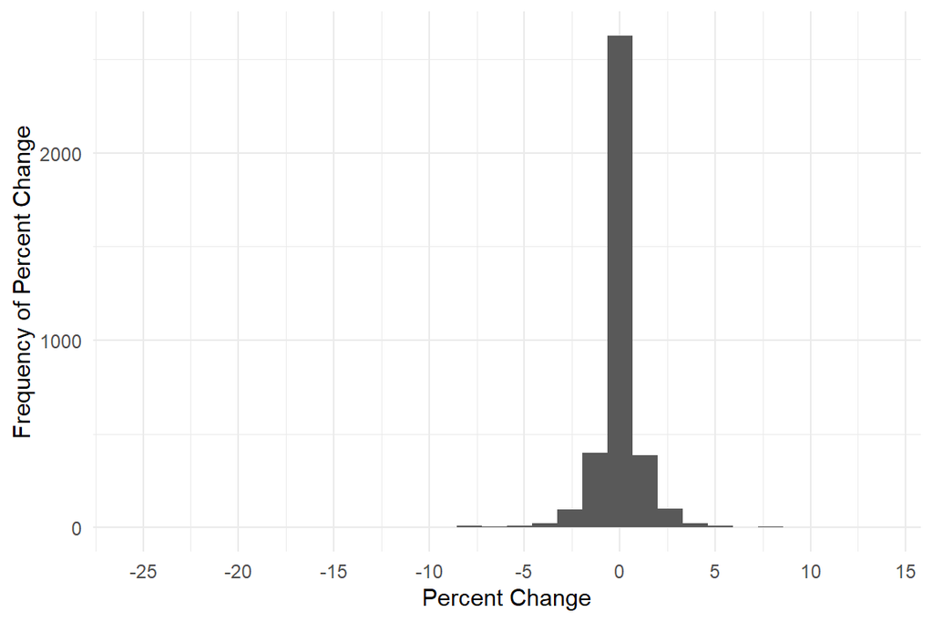

```r
ggplot(data=endpoint_review_wide) +
  geom_histogram(aes(x=perc.change))+
  xlab('Percent Change')+
  ylab('Frequency of Percent Change')+
  scale_x_continuous(breaks = seq(-30, 30, 5)) +
  theme_bw()+
  theme(axis.title.x = element_text(face='bold', size=14),
        axis.title.y = element_text(face='bold', size=14),
        axis.text.x = element_text(size=12),
        axis.text.y = element_text(size=12)) + theme_minimal()
```

## 8.3 SC New Endpoints

The 58 new endpoints released in v4.3 with single-conc data include:

```r
new.sc.aeids <- setdiff(new.sc2$aeid, old.sc2$aeid)

datatable(ace.new[aeid %in% new.sc.aeids, c('aeid','assay_component_endpoint_name')],
          filter='top',
          options=list(pagelength=25, autoWidth=FALSE,  scrollX=TRUE, initComplete = JS(
    "function(settings, json) {",
    "$('body').css({'font-family': 'Calibri'});",
    "}"
  )))
```

|  | aeid | assay_component_endpoint_name |
| --- | --- | --- |
| 1 | 664 | NVS_GPCR_rAdra1A |
| 2 | 675 | NVS_GPCR_rmMGluR5 |
| 3 | 679 | NVS_GPCR_rOpiate_NonSelective |
| 4 | 2606 | ERF_TW_ENZ_hPDE4D2 |
| 5 | 2631 | ERF_TW_GPCR_hADRA2A |
| 6 | 2633 | ERF_TW_GPCR_hADRB1 |
| 7 | 2640 | ERF_TW_GPCR_hCCKAR |
| 8 | 2688 | ERF_TW_NR_hRARa |
| 9 | 2705 | ERF_TW_NR_hPPARG |
| 10 | 3071 | HCAN_AUR_hTPO |

[output cut: 48 more lines]

# 9 Notable Software Updates

The ToxCast Data Analysis Pipeline (`tcpl`) is an R package that manages, curve-fits, plots, and stores ToxCast data to populate its linked MySQL database, invitrodb. The package was developed for the chemical screening data generated by the US EPA’s Toxicity Forecaster (ToxCast) program. `tcpl` can be used to support diverse chemical screening efforts. `tcpl` v3.3.0, along with the dependency package `tcplfit2` v0.1.8, was used to process data in invitrodb v4.3. Notable updates to `tcpl` and `tcplfit2` are described below. For more details, see the [`tcpl` v3.3](https://github.com/USEPA/CompTox-ToxCast-tcpl/releases/tag/v3.3.0) and [`tcplfit2` v0.1.8](https://github.com/USEPA/CompTox-ToxCast-tcplFit2/releases/tag/v0.1.8) release notes.

[figure not shown]

## 9.1 tcplfit2 Top Determination

Previously in `tcplfit2`, the ‘top’ value was differentially defined for the various models included in the package and the resulting value thus was inconsistent across best fitting (i.e. winning) models. The solution was to define ‘top’ consistently as the ‘maximum predicted change in response from baseline within the experimental concentration range’. Top is now either estimated via the derivative, if available/applicable, or empirically using the predicted responses from the best fitting model within the experimental concentration range. In effect, this resolved odd behaviors with non-monotonic models (e.g. poly2), which previously assumed the predicted response at the maximum concentration as the top. This update resulted in more accurate continuous hitcall values across models, as ‘top’ is used in the calculation for two of three proportional weights.

## 9.2 tcpl Plotting

`tcplPlot()` is `tcpl`’s single flexible plotting function, allowing for interactive yet consistent visualization of concentration-response curves via customizable parameters. The standalone plotting utility is built with the R libraries `plotly` and `ggplot2` to display the additional curve-fitting models. The `tcplPlot()` function requires the selection of a type (`type`), field (`fld`), and value (`val`) to load the necessary data and display the associated plots.

In v3.3, `tcplPlot()` gained a compare parameter, which replaces the compare.val parameter, for selecting a plot-data field by which samples are grouped into comparison plots. tcplPlot() also gains group.fld, group.threshold, and hide_losing_models parameters, providing more customizability to comparison and individual concentration-response plots alike. See [`tcpl`’s vignette](https://CRAN.R-project.org/package=tcpl) for comprehensive documentation.

# 10 Administered Equivalent Doses

The highest level assumption in the *in vitro* to *in vivo* extrapolation (IVIVE) approach employed here is that the *in vitro* bioactive concentration in a ToxCast assay endpoint is roughly equivalent to a human plasma concentration *in vivo*. For a review of IVIVE and httk models for it, please see: [Breen et al, 2021](https://pubmed.ncbi.nlm.nih.gov/34056988/)

For invitrodb v4.3 onward, the level 7 (MC7) table contains pre-generated AED values using several potency metrics from invitrodb and a subset of models from the High-throughput Toxicokinetics R package httk . As implemented, this MC7 table provides users with pre-calculated estimates of the *in vivo* human administered dose (mg/kg/day) based on the *in vitro* bioactive concentrations as seen in ToxCast screening data. AEDs can also be calculated *ad hoc* for ToxCast potency estimates using the [High-throughput Toxicokinetics R package (httk)](https://cran.r-project.org/web/packages/httk/index.html). See [`tcpl`’s vignette under Data Interpretation>Administered Equivalent Doses](https://CRAN.R-project.org/package=tcpl) for more information.

The invitrodb v4.3 MC7 table was generated using httk v2.6.1, which includes the new “sumclearances” model, as described in [Wambaugh et al. (2025)](https://pubs.acs.org/doi/10.1021/acs.estlett.4c00967). The “sumclearances” model includes exhalation and assumes steady state, therefore using the “pbtk” and “3compartmentss” model was deemed duplicative since it also runs at steady-state and lacks exhalation component for semi-volatiles.

# 11 Cytotoxicity Burst Distribution

Estimates of chemical concentrations that elicit cytotoxicity and/or cell stress have been informative for contextualizing bioactivity screening data in ToxCast by providing information on the likelihood that these data may be confounded by assay interference resulting from cytotoxicity and/or cell stress, particularly when a parallel or in-well estimate of cell viability is unavailable. As such, general estimates of the median and lower bound concentrations that might elicit cytotoxicity and/or cell stress in vitro have previously been calculated using the **tcplCytoPt** function, which considers activity across a suite of cell-based assays based on updates to previous work [(Judson et al., 2016)](https://pubmed.ncbi.nlm.nih.gov/27605417/).

These derived concentration threshold values have been released in the “cytotox” table of invitrodb and are also provided on the [CompTox Chemicals Dashboard](https://comptox.epa.gov/dashboard/batch-search) Bioactivity Summary Plot. In some use cases, this cytotoxicity-associated “burst” threshold may be used to infer activity that may represent a false positive response ascribed to assay interference, with the stringency of this interpretation subject to the use case. See [`tcpl`’s vignette, under Data Interpretation>Cytotoxicity Burst Distribution](https://CRAN.R-project.org/package=tcpl), for more information.

In v4.3, a slightly higher global MAD was calculated at 0.1752002 compared to 0.1703165 in v4.2. The figures below depict impacts to distributions of the median and lower bounds of the cytotoxicity burst in v4.3 compared to v4.2. In the table, a median and median absolute deviation of these values is calculated per version (with *default* median and lower bounds are excluded).

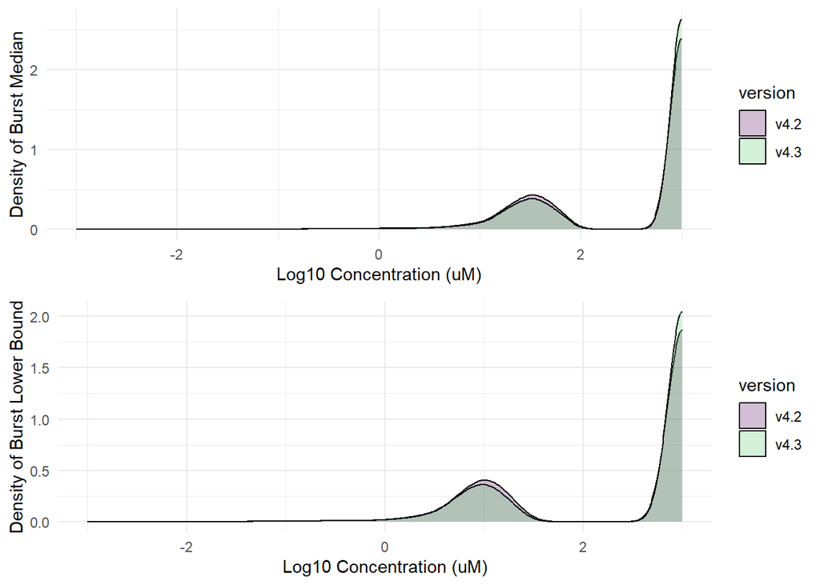

|  | version | median_median_log10_um | mad_median_log10 | median_lower_bnd_log10_um | mad_lower_bnd_log10_um |
| --- | --- | --- | --- | --- | --- |
| 1 | v4.3 | 1.463667172071975 | 0.2688512370650645 | 0.9380665120205781 | 0.2688512370650643 |
| 2 | v4.2 | 1.469355334168822 | 0.2772845061898498 | 0.9584057849371024 | 0.2772845061898498 |

# 12 OECD GD211 Assay Description Documents

Given ToxCast includes a heterogeneous set of assays across a diverse biological space, annotations in the database help flexibly aggregate and differentiate processed data whereas assay documentation aligned with international standardization efforts can make ToxCast data more useful and interpretable for use in decision-making. Assay Element and Auxiliary Annotation structure is described in `tcpl`’s Introduction vignette, whereas how to access databased annotation information is described in the Data Retrieval vignettes.

The [OECD Guidance Document 211 (GD211)](https://ntp.niehs.nih.gov/sites/default/files/iccvam/suppdocs/feddocs/oecd/oecd-gd211-2014-508.pdf) is a standard for comprehensive assay documentation describing non-guideline in vitro test methods and their interpretation. This template is intended to harmonize non-guideline, *in vitro* method descriptions to allow assessment of the relevance of the test method for biological responses of interest and the quality of the data produced. Unlike the assay element annotations which are often short in a standardized format or use a controlled term list, the assay_descriptions fields have no character limit for text. Information has been released in the “assay_descriptions” table of invitrodb and are also provided within a compiled report of these assay description documents, available on the [ToxCast Downloadable Data page](https://www.epa.gov/chemical-research/exploring-toxcast-data-downloadable-data).

# 13 Analytical QC and Applicability Domain

There is high value in understanding the outcomes of solubilization and chemical stability in the vehicle chosen to solubilize the chemical, i.e., whether the chemical is within the applicability domain for *in vitro* screening. In invitrodb v4.3, all assays are aqueous based and not closed systems (i.e., no aerosol or volatile chambers used). Understanding DMSO solvation and stability in DMSO informs what chemicals and samples should screened in future experiments. It also helps inform future structural models to understand which chemicals will be stable and detectable in solution, and further provide insight into possible degradation products that could be synthesized or purchased. Most critically, this information promotes understanding of uncertainty in estimates of initial experimental concentration of chemicals. Note that we place emphasis on the time 0 or T0 data for understanding whether a chemical was likely present in assays at the time of screening; time 4 or T4 represents DMSO samples left at room temperature with no dessication for 4 months, and does not represent standard chemical handling practice for ToxCast assays (only samples for some Tox21 assays were handled this way).

To establish a resource of applicability domain information at the substance and sample level, a retrospective analysis of the [analytical QC data for the ToxCast/Tox21 chemical library](https://tripod.nih.gov/tox/samples) was conducted. This involved reviewing legacy reports from gas chromatography-mass spectrometry (GCMS), liquid chromatography-mass spectrometry (LCMS), and Nuclear Magnetic Resonance (NMR) experiments. For details regarding the measurement of data, please see: [Richard et al., 2024](https://pubs.acs.org/doi/10.1021/acs.chemrestox.4c00330). Additional analytical QC, such as for the PFAS chemical library, and integration efforts are ongoing. The “chemical_analytical_qc” table of invitrodb stores this information from a retrospective analysis and surfaces it within the ToxCast Bioactivity module of [CompTox Chemicals Dashboard](https://comptox.epa.gov/dashboard/batch-search) v2.6.0. Visit the Analytical QC list on AMOS (Analytical Methods & Open Spectra) for access to the complete repository of source documents.

v4.3 include 8843 substance-level and 33690 sample-level calls. 6480 (73.2782992%) substance-level calls pass, whereas 25984 (77.1267438%) of sample-level calls pass. The analytical QC results from original NCATS sample ids have been connected to ToxCast sample ids through source bottle lineage. This update includes refined logic to generate this table now includes analytical QC data, if available, for chemicals where physico-chemical properties could not be calculated and TOX21 samples that could not be mapped to EPA sample ids screened in ToxCast.

Consult full table for additional details, including cautionary flags and annotations, as well as [`tcpl`’s vignette, under Data Interpretation>Analytical QC & Applicability Domain](https://CRAN.R-project.org/package=tcpl), for more information.

# 14 Reproducibility

ToxCast provides a standard for consistent and reproducible data processing for diverse, targeted bioactivity assay data with readily available documentation and a unified FAIR software approach. As part of EPA’s commitment to gather and share its chemical data in open and transparent ways, all ToxCast chemical data is publicly available. For more information, visit the [ToxCast Home Page](https://www.epa.gov/comptox-tools/toxicity-forecasting-toxcast)